# Reproducible Research: Course Project 1

This particular course project pertains to data that was collected from an individual using a personal activity monitoring device. The following bullets are the requirements for submission:

- Code for reading in the dataset and/or processing the data
- Histogram of the total number of steps taken each day
- Mean and median number of steps taken each day
- Time series plot of the average number of steps taken
- The 5-minute interval that, on average, contains the maximum number of steps
- Code to describe and show a strategy for imputing missing data
- Histogram of the total number of steps taken each day after missing values are imputed
- Panel plot comparing the average number of steps taken per 5-minute interval across weekdays and weekends
- All of the R code needed to reproduce the results (numbers, plots, etc.) in the report

### Read in the dataset and process the data.

```r
activity <- read.csv("activity.csv", stringsAsFactors = FALSE)
activity$date <- as.Date(activity$date)
summary(activity)
```

```
##      steps             date               interval
##  Min.   :  0.00   Min.   :2012-10-01   Min.   :   0.0
##  1st Qu.:  0.00   1st Qu.:2012-10-16   1st Qu.: 588.8
##  Median :  0.00   Median :2012-10-31   Median :1177.5
##  Mean   : 37.38   Mean   :2012-10-31   Mean   :1177.5
##  3rd Qu.: 12.00   3rd Qu.:2012-11-15   3rd Qu.:1766.2
##  Max.   :806.00   Max.   :2012-11-30   Max.   :2355.0
##  NA's   :2304
```

### Combine the total steps for each day and create a histogram.

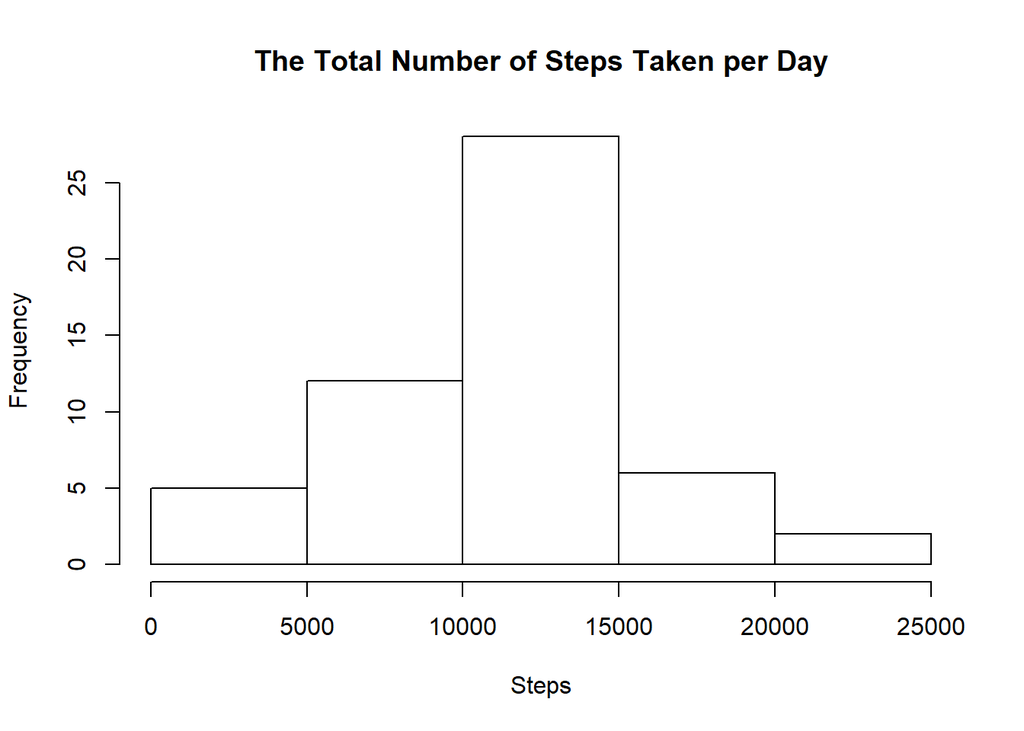

```r
activitysum <- aggregate(steps ~ date, activity, sum)
hist(activitysum$steps, xlab= "Steps", main = "The Total Number of Steps Taken per Day")
```

### Calculate the mean and median number of steps taken each day.

```r
mean(activitysum$steps)
```

```
## [1] 10766.19
```

```r
median(activitysum$steps)
```

```
## [1] 10765
```

### Create a time series plot of the average number of steps taken.

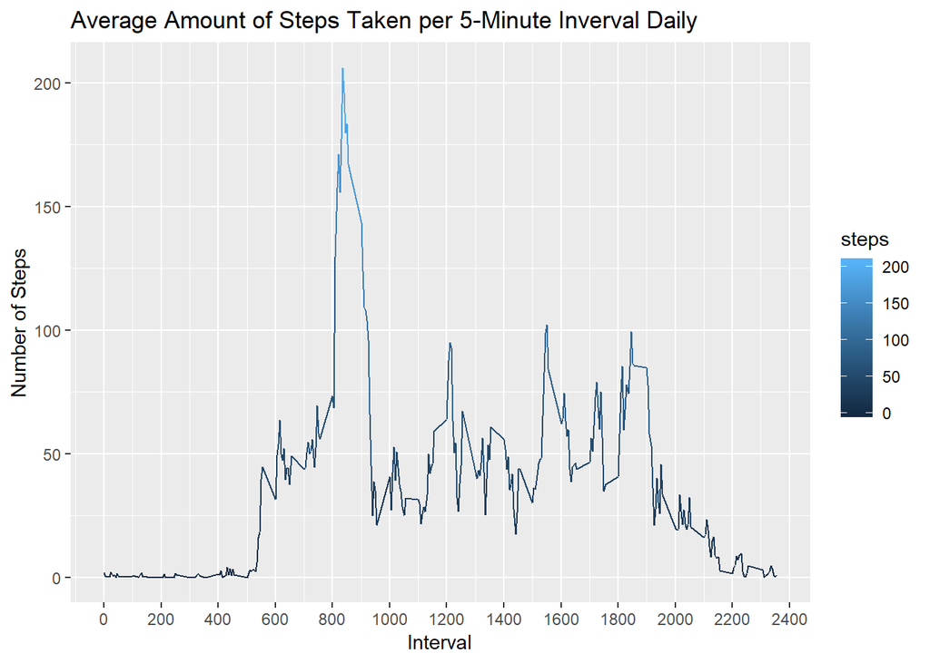

```r
library(ggplot2)
#Calculate the average number of steps by interval first.
activityavg <- aggregate(steps ~ interval, activity, mean)

avgsteps <- ggplot(activityavg, aes(interval, steps, colour=steps)) + geom_line() + scale_x_continuous(breaks = seq(0, 2500, by = 200))
avgsteps + labs(title = "Average Amount of Steps Taken per 5-Minute Inverval Daily", x="Interval", y="Number of Steps")
```

### Maximum Number of Steps

Which 5-minute interval, on average across all the days in the dataset, contains the maximum number of steps?

```r
activityavg[match(max(activityavg$steps),activityavg$steps),1]
```

```
## [1] 835
```

### Strategy for imputing missing data.

```r
#Calculate the total number of missing values in the dataset (total number of NAs)
sum(is.na(activity))
```

```
## [1] 2304
```

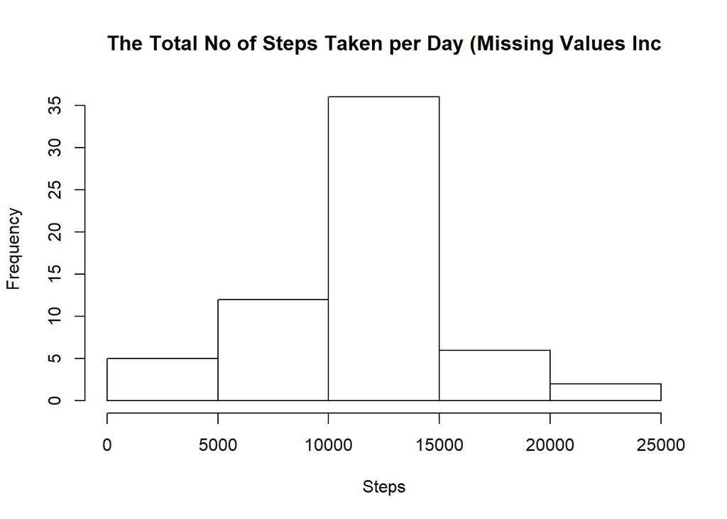

```r
#Use the mean values from each five minute intervals
activity$newsteps <- ifelse(is.na(activity$steps)==T, activityavg[match(activity$interval, activityavg$interval),2], activity$steps)

#Combine the total steps for each day.
navaluessum <- aggregate(newsteps ~ date, activity, sum)

#Plot a histogram of the total number of steps taken each day.
hist(navaluessum$newsteps, xlab= "Steps", main = "The Total No of Steps Taken per Day (Missing Values Inc")
```

### Calculate and report the mean and median total number of steps taken per day.

```r
#Do these values differ from the estimates from the first part of the assignment?
#1st Time
mean(activitysum$steps)
```

```
## [1] 10766.19
```

```r
median(activitysum$steps)
```

```
## [1] 10765
```

```r
#2nd Time (with NA values included)
mean(navaluessum$newsteps)
```

```
## [1] 10766.19
```

```r
median(navaluessum$newsteps)
```

```
## [1] 10766.19
```

```r
#Create a new factor variable in the dataset with two levels - "weekday" and "weekend" indicating whether a given date is a weekday or weekend day.
weekdays1 <- c('Monday', 'Tuesday', 'Wednesday', 'Thursday', 'Friday')
activity$weekdayandend <- factor((weekdays(activity$date) %in% weekdays1), levels=c(FALSE, TRUE), labels=c('weekend', 'weekday'))

#Combine only the three columns that are needed to answer this question.
wkdaywkend <- cbind.data.frame(activity[,3], activity[,4], activity[,5])
colnames(wkdaywkend) <- c("Interval", "Steps", "Day")
```

### Are there differences in activity patterns between weekdays and weekends?

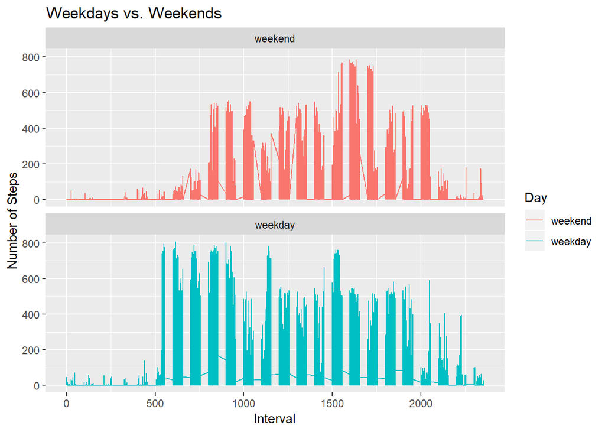

```r
#Make a panel plot containing a time series plot to compare the differences between weekdays and weekends.
ggplot(wkdaywkend, aes(x=Interval, y=Steps, color= Day)) + geom_line() + labs(title = "Weekdays vs. Weekends", x="Interval", y="Number of Steps") +facet_wrap(~`Day`, ncol =1, nrow = 2)
```